# Hierarchical Compartmental Models for Loss Reserving

Jake Morris

July 17, 2018

# Extending the Growth Curve Approach

## Exponential Growth Function

- Exponential growth for rate of payment $k_{p}$ defined as:
  $$GF_{t} = 1-e^{-k_{p} \cdot t}$$

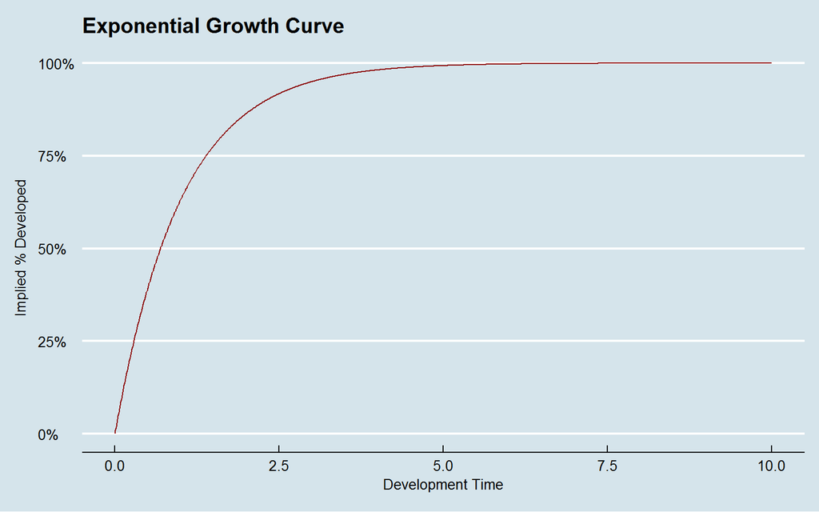

## Exponential Growth as an ODE system

- Define $EX_{t}$ as exposure % at development time t
- Assume $EX_{0} = 1$ and $EX_{t} + GF_{t} = 1$
- Growth function is a solution to ODEs:
- $$dEX_{t}/dt = -k_{p} \cdot EX_{t}$$
  $$dGF_{t}/dt = k_{p} \cdot EX_{t}$$
- $$EX_{t} = e^{-k_{p} \cdot t}$$
  $$GF_{t} = 1-e^{-k_{p} \cdot t}$$

## Exponential Growth Model as an ODE system

- Assume $EX_{0} = \text{Premiums} = P$
- Define $PD_{t}$ as cumulative paid claims at time t
- Allow a multiple of exposure, $ULR$, to become paid
- $$dEX_{t}/dt = -k_{p} \cdot EX_{t}$$
  $$dPD_{t}/dt = k_{p} \cdot ULR \cdot EX_{t}$$
- $$EX_{t} = P \cdot (1-GF_{t})$$
  $$PD_{t} = P \cdot ULR \cdot GF_{t}$$

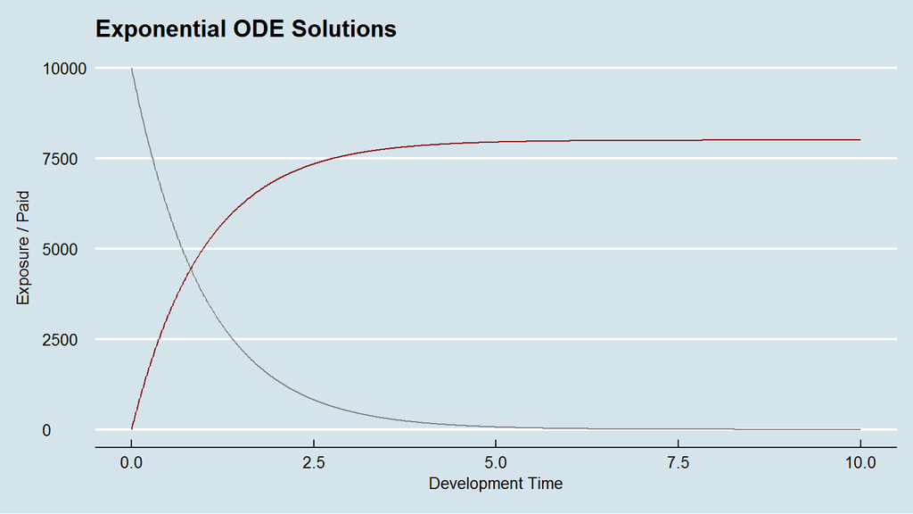

## Compartmental Model Representation

- Systems of ODEs can be written schematically as **compartmental models**:

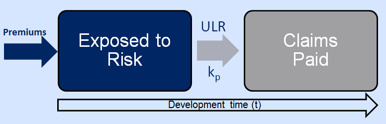

- Readily extensible framework for modelling the claims process

# Compartmental Reserving Models

## Base Model Schematic

- Introduce additional compartment for reported claims
  - Define $k_{er}$ as rate claims occur and are reported
- Split $ULR$ into multiplicative components:
  - Reported Loss Ratio ($RLR$)
  - Reserve Robustness Factor ($RRF$)

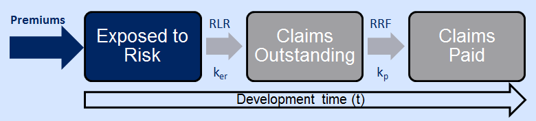

## Base Model ODEs

- $$\begin{gathered}
  \begin{align}
  \tfrac{dEX_{t}}{dt} &= -k_{er} \cdot EX_{t} \\
  \tfrac{dOS_{t}}{dt} &= k_{er} \cdot RLR \cdot EX_{t} - k_{p} \cdot OS_{t} \\
  \tfrac{dPD_{t}}{dt} &= k_{p} \cdot RRF \cdot OS_{t}
  \end{align}
  \end{gathered}$$

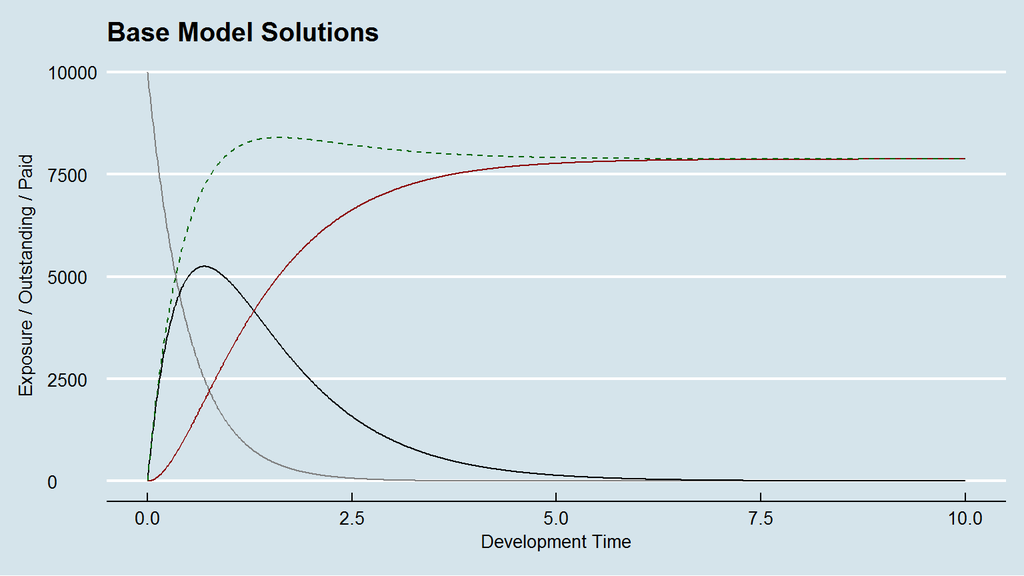

## Extending the Model

- Constant rates of reporting and payment rarely hold
  - Delays in reporting post-incident
  - Payment delays for larger claims
- Allow $k_{er}$ and $k_{p}$ to depend on development time, $t$
  - Many potential functions
- $$k_{er}(t) = \beta_{er} \cdot t$$
  $$k_{p}(t) = \beta_{1,p} / (\beta_{2,p} + t)$$

## Extended Model ODEs

- $$\begin{gathered}
  \begin{align}
  \tfrac{dEX_{t}}{dt} &= -\beta_{er} \cdot t \cdot EX_{t} \\
  \tfrac{dOS_{t}}{dt} &= \beta_{er} \cdot t \cdot RLR \cdot EX_{t} - \tfrac{\beta_{1,p}} {(\beta_{2,p} + t)} \cdot OS_{t} \\
  \tfrac{dPD_{t}}{dt} &= \tfrac{\beta_{1,p}} {(\beta_{2,p} + t)} \cdot RRF \cdot OS_{t}
  \end{align}
  \end{gathered}$$

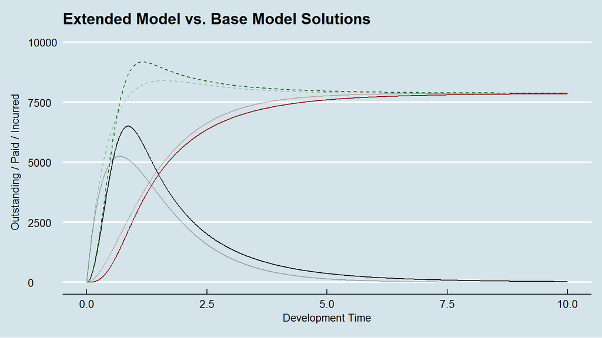

# Hierarchical Compartmental Reserving Model

## Model Specification

- $$\begin{aligned}
  \begin{bmatrix}
  OS_{ij}, PD_{ij}
  \end{bmatrix}^{T} = \
  y_{ij} &\thicksim \mathcal{N}(\mu_{ij},\ \sigma^{2}_{[\delta]}) \\
  \mu_{ij} &= P_{i} \cdot f(\delta_{ij}, t_{j}, k_{er}, RLR_{[i]}, k_{p}, RRF_{[i]}) \\
  \\
  f(\delta_{ij},t_{j},\dots) &
  = (1 - \delta_{ij}) \cdot \hat {\mbox{OS}}(t_{j}, k_{er}, RLR_{[i]}, k_{p}) \ + \\
  & \ \ \ \ \ \ \delta_{ij} \cdot \hat {\mbox{PD}}( t_{j}, k_{er}, RLR_{[i]}, k_{p}, RRF_{[i]}) \\
  \\
  \delta_{ij} &=
  \begin{cases}
  0 & \text{if } y_{ij} = OS_{ij} \\
  1 & \text{if } y_{ij} = PD_{ij}
  \end{cases} \\
  \\
  \begin{pmatrix} RLR_{[i]} \\ RRF_{[i]}\end{pmatrix} &\thicksim
  \mathcal{N} \left(
  \begin{pmatrix}
  \mu_{RLR} \\
  \mu_{RRF}
  \end{pmatrix},
  \begin{pmatrix}
  \sigma_{_{RLR}}^2 & 0\\
  0 & \sigma_{_{RRF}}^2
  \end{pmatrix}
  \right)
  \end{aligned}$$

## Priors

- Prior assumptions driven by domain knowledge:
  - Profitability
  - Case reserving strength
  - Reporting / Payment speed

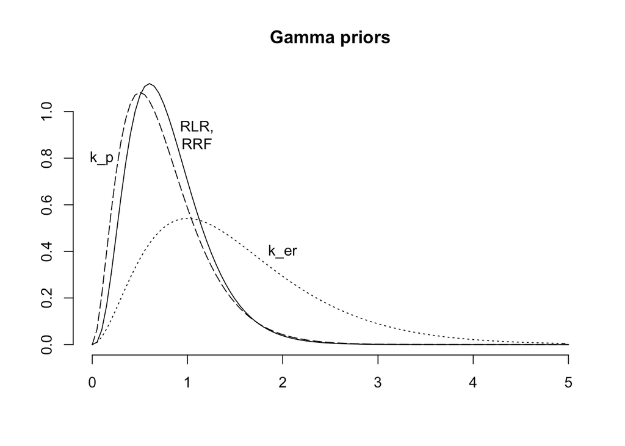

## ‘brms’ Code

```r
fml <-
  loss_train ~ premiums * (
     (1 - delta) * (RLR*ker/(ker - kp) * (exp(-kp*dev) - exp(-ker*dev))) +
      delta * (RLR*RRF/(ker - kp) * (ker *(1 - exp(-kp*dev)) - kp*(1 - exp(-ker*dev))))
   )

b1 <- brm(bf(fml,
             ker ~ 1, kp ~ 1,
             RLR ~ 1 + (1 | accident_year),
             RRF ~ 1 + (1 | accident_year),
             sigma ~ 0 + deltaf,
             nl = TRUE),
          data = lossData0[cal <= max(accident_year)],
          family = brmsfamily("gaussian", link_sigma = "log"),
          prior = c(prior(gamma(4, 5), nlpar = "RLR", lb=0),
                    prior(gamma(4, 5), nlpar = "RRF", lb=0),
                    prior(gamma(3, 2), nlpar = "ker", lb=0),
                    prior(gamma(3, 4), nlpar = "kp", lb=0)),
          control = list(adapt_delta = 0.999, max_treedepth=15),
          seed = 1234, iter = 1000)
```

## Posterior Predictive Checks: Outstanding

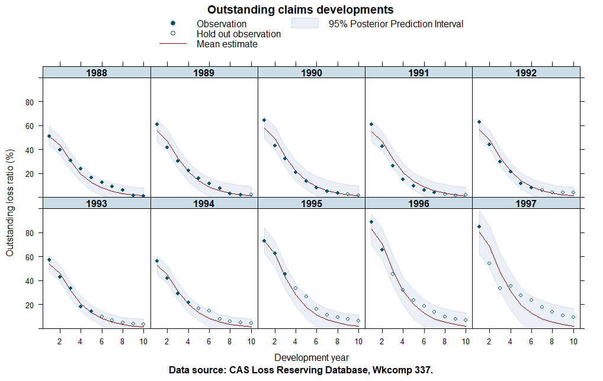

## Posterior Predictive Checks: Paid

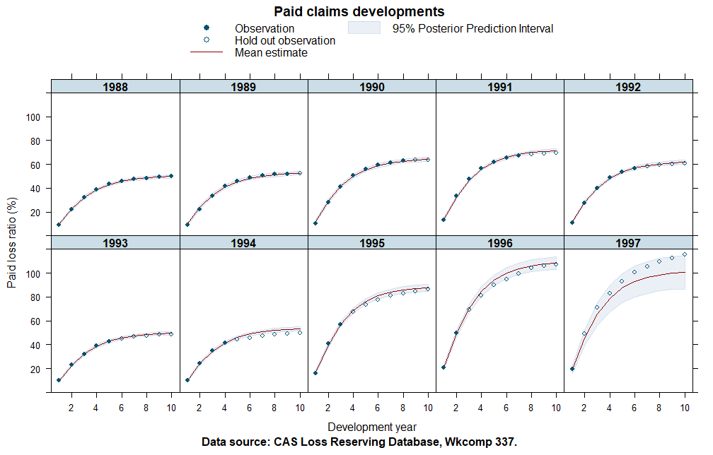

## Exercise Questions

- Is a Normal observation model appropriate?
- How sensitive is the model to alternative priors?
- Are $RLR_{i}$ and $RRF_{i}$ likely to be independent?
- How might we increase model flexibility?